# Risk Factor Analysis

## Outcome Variable

**Outcome Variable:** stunted

## Predictor Variables

**Intervention Variable:** mwtkg

**Adjustment Set:**

unadjusted

## Stratifying Variables

The analysis was stratified on these variable(s):

- agecat
- studyid
- country

## Data Summary

| agecat | studyid | country | mwtkg | stunted | n_cell | n |
| --- | --- | --- | --- | --- | --- | --- |
| Birth | ki0047075b-MAL-ED | BANGLADESH | >=57.5 | 0 | 43 | 246 |
| Birth | ki0047075b-MAL-ED | BANGLADESH | >=57.5 | 1 | 7 | 246 |
| Birth | ki0047075b-MAL-ED | BANGLADESH | <42.5 | 0 | 44 | 246 |
| Birth | ki0047075b-MAL-ED | BANGLADESH | <42.5 | 1 | 9 | 246 |
| Birth | ki0047075b-MAL-ED | BANGLADESH | [42.5-50) | 0 | 68 | 246 |
| Birth | ki0047075b-MAL-ED | BANGLADESH | [42.5-50) | 1 | 17 | 246 |
| Birth | ki0047075b-MAL-ED | BANGLADESH | [50-57.5) | 0 | 49 | 246 |
| Birth | ki0047075b-MAL-ED | BANGLADESH | [50-57.5) | 1 | 9 | 246 |
| 6 months | ki0047075b-MAL-ED | BANGLADESH | >=57.5 | 0 | 43 | 241 |
| 6 months | ki0047075b-MAL-ED | BANGLADESH | >=57.5 | 1 | 6 | 241 |
| 6 months | ki0047075b-MAL-ED | BANGLADESH | <42.5 | 0 | 39 | 241 |
| 6 months | ki0047075b-MAL-ED | BANGLADESH | <42.5 | 1 | 15 | 241 |
| 6 months | ki0047075b-MAL-ED | BANGLADESH | [42.5-50) | 0 | 60 | 241 |
| 6 months | ki0047075b-MAL-ED | BANGLADESH | [42.5-50) | 1 | 23 | 241 |
| 6 months | ki0047075b-MAL-ED | BANGLADESH | [50-57.5) | 0 | 54 | 241 |
| 6 months | ki0047075b-MAL-ED | BANGLADESH | [50-57.5) | 1 | 1 | 241 |
| 24 months | ki0047075b-MAL-ED | BANGLADESH | >=57.5 | 0 | 32 | 212 |
| 24 months | ki0047075b-MAL-ED | BANGLADESH | >=57.5 | 1 | 11 | 212 |
| 24 months | ki0047075b-MAL-ED | BANGLADESH | <42.5 | 0 | 13 | 212 |
| 24 months | ki0047075b-MAL-ED | BANGLADESH | <42.5 | 1 | 32 | 212 |
| 24 months | ki0047075b-MAL-ED | BANGLADESH | [42.5-50) | 0 | 32 | 212 |
| 24 months | ki0047075b-MAL-ED | BANGLADESH | [42.5-50) | 1 | 41 | 212 |
| 24 months | ki0047075b-MAL-ED | BANGLADESH | [50-57.5) | 0 | 37 | 212 |
| 24 months | ki0047075b-MAL-ED | BANGLADESH | [50-57.5) | 1 | 14 | 212 |
| Birth | ki0047075b-MAL-ED | BRAZIL | >=57.5 | 0 | 111 | 184 |
| Birth | ki0047075b-MAL-ED | BRAZIL | >=57.5 | 1 | 11 | 184 |
| Birth | ki0047075b-MAL-ED | BRAZIL | <42.5 | 0 | 9 | 184 |
| Birth | ki0047075b-MAL-ED | BRAZIL | <42.5 | 1 | 3 | 184 |
| Birth | ki0047075b-MAL-ED | BRAZIL | [42.5-50) | 0 | 11 | 184 |
| Birth | ki0047075b-MAL-ED | BRAZIL | [42.5-50) | 1 | 2 | 184 |

[output cut: 296 more lines]

The following strata were considered:

- agecat: 24 months, studyid: ki0047075b-MAL-ED, country: BANGLADESH
- agecat: 24 months, studyid: ki0047075b-MAL-ED, country: BRAZIL
- agecat: 24 months, studyid: ki0047075b-MAL-ED, country: INDIA
- agecat: 24 months, studyid: ki0047075b-MAL-ED, country: NEPAL
- agecat: 24 months, studyid: ki0047075b-MAL-ED, country: PERU
- agecat: 24 months, studyid: ki0047075b-MAL-ED, country: SOUTH AFRICA
- agecat: 24 months, studyid: ki0047075b-MAL-ED, country: TANZANIA, UNITED REPUBLIC OF
- agecat: 24 months, studyid: ki1017093-NIH-Birth, country: BANGLADESH
- agecat: 24 months, studyid: ki1017093b-PROVIDE, country: BANGLADESH
- agecat: 24 months, studyid: ki1017093c-NIH-Crypto, country: BANGLADESH
- agecat: 24 months, studyid: ki1066203-TanzaniaChild2, country: TANZANIA, UNITED REPUBLIC OF
- agecat: 24 months, studyid: ki1119695-PROBIT, country: BELARUS
- agecat: 24 months, studyid: ki1126311-ZVITAMBO, country: ZIMBABWE
- agecat: 24 months, studyid: ki1148112-LCNI-5, country: MALAWI
- agecat: 6 months, studyid: ki0047075b-MAL-ED, country: BANGLADESH
- agecat: 6 months, studyid: ki0047075b-MAL-ED, country: BRAZIL
- agecat: 6 months, studyid: ki0047075b-MAL-ED, country: INDIA
- agecat: 6 months, studyid: ki0047075b-MAL-ED, country: NEPAL
- agecat: 6 months, studyid: ki0047075b-MAL-ED, country: PERU
- agecat: 6 months, studyid: ki0047075b-MAL-ED, country: SOUTH AFRICA
- agecat: 6 months, studyid: ki0047075b-MAL-ED, country: TANZANIA, UNITED REPUBLIC OF
- agecat: 6 months, studyid: ki1000304b-SAS-CompFeed, country: INDIA
- agecat: 6 months, studyid: ki1017093-NIH-Birth, country: BANGLADESH
- agecat: 6 months, studyid: ki1017093b-PROVIDE, country: BANGLADESH
- agecat: 6 months, studyid: ki1017093c-NIH-Crypto, country: BANGLADESH
- agecat: 6 months, studyid: ki1066203-TanzaniaChild2, country: TANZANIA, UNITED REPUBLIC OF
- agecat: 6 months, studyid: ki1119695-PROBIT, country: BELARUS
- agecat: 6 months, studyid: ki1126311-ZVITAMBO, country: ZIMBABWE
- agecat: 6 months, studyid: ki1148112-LCNI-5, country: MALAWI
- agecat: Birth, studyid: ki0047075b-MAL-ED, country: BANGLADESH
- agecat: Birth, studyid: ki0047075b-MAL-ED, country: BRAZIL
- agecat: Birth, studyid: ki0047075b-MAL-ED, country: INDIA
- agecat: Birth, studyid: ki0047075b-MAL-ED, country: NEPAL
- agecat: Birth, studyid: ki0047075b-MAL-ED, country: PERU
- agecat: Birth, studyid: ki0047075b-MAL-ED, country: SOUTH AFRICA
- agecat: Birth, studyid: ki0047075b-MAL-ED, country: TANZANIA, UNITED REPUBLIC OF
- agecat: Birth, studyid: ki1000304b-SAS-CompFeed, country: INDIA
- agecat: Birth, studyid: ki1017093-NIH-Birth, country: BANGLADESH
- agecat: Birth, studyid: ki1017093c-NIH-Crypto, country: BANGLADESH
- agecat: Birth, studyid: ki1119695-PROBIT, country: BELARUS
- agecat: Birth, studyid: ki1126311-ZVITAMBO, country: ZIMBABWE

### Dropped Strata

Some strata were dropped due to rare outcomes:

- agecat: 6 months, studyid: ki0047075b-MAL-ED, country: BANGLADESH
- agecat: Birth, studyid: ki0047075b-MAL-ED, country: BRAZIL
- agecat: 6 months, studyid: ki0047075b-MAL-ED, country: BRAZIL
- agecat: 24 months, studyid: ki0047075b-MAL-ED, country: BRAZIL
- agecat: Birth, studyid: ki0047075b-MAL-ED, country: INDIA
- agecat: 6 months, studyid: ki0047075b-MAL-ED, country: NEPAL
- agecat: 24 months, studyid: ki0047075b-MAL-ED, country: NEPAL
- agecat: Birth, studyid: ki0047075b-MAL-ED, country: NEPAL
- agecat: Birth, studyid: ki0047075b-MAL-ED, country: PERU
- agecat: Birth, studyid: ki0047075b-MAL-ED, country: SOUTH AFRICA
- agecat: 6 months, studyid: ki0047075b-MAL-ED, country: SOUTH AFRICA
- agecat: 24 months, studyid: ki0047075b-MAL-ED, country: SOUTH AFRICA
- agecat: Birth, studyid: ki0047075b-MAL-ED, country: TANZANIA, UNITED REPUBLIC OF
- agecat: 6 months, studyid: ki0047075b-MAL-ED, country: TANZANIA, UNITED REPUBLIC OF
- agecat: 24 months, studyid: ki0047075b-MAL-ED, country: TANZANIA, UNITED REPUBLIC OF
- agecat: Birth, studyid: ki1000304b-SAS-CompFeed, country: INDIA
- agecat: Birth, studyid: ki1017093-NIH-Birth, country: BANGLADESH
- agecat: Birth, studyid: ki1017093c-NIH-Crypto, country: BANGLADESH
- agecat: 6 months, studyid: ki1066203-TanzaniaChild2, country: TANZANIA, UNITED REPUBLIC OF
- agecat: 24 months, studyid: ki1066203-TanzaniaChild2, country: TANZANIA, UNITED REPUBLIC OF
- agecat: Birth, studyid: ki1119695-PROBIT, country: BELARUS
- agecat: 24 months, studyid: ki1119695-PROBIT, country: BELARUS
- agecat: 24 months, studyid: ki1126311-ZVITAMBO, country: ZIMBABWE

## Methods Detail

We’re interested in the causal parameters $E[Y_a]$ for all values of $a \in \mathcal{A}$. These parameters represent the mean outcome if, possibly contrary to fact, we intervened to set all units to have $A=a$. Under the randomization and positivity assumptions, these are identified by the statistical parameters $\psi_a=E_W[E_{Y|A,W}(Y|A=a,W)]$. In addition, we’re interested in the mean of $Y$, $E[Y]$ under no intervention (the observed mean). We will estimate these parameters by using SuperLearner to fit the relevant likelihood factors – $E_{Y|A,W}(Y|A=a,W)$ and $p(A=a|W)$, and then updating our likelihood fit using a joint TMLE.

For unadjusted analyses ($W=\{\}$), initial likelihoods were estimated using Lrnr_glm to estimate the simple $E(Y|A)$ and Lrnr_mean to estimate $p(A)$. For adjusted analyses, a small library containing Lrnr_glmnet, Lrnr_xgboost, and Lrnr_mean was used.

Having estimated these parameters, we will then use the delta method to estimate relative risks and attributable risks relative to a prespecified baseline level of $A$.

# Results Detail

## Results Plots

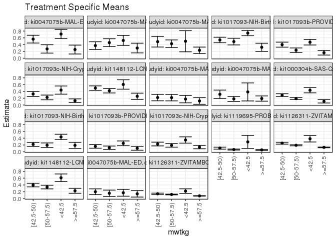

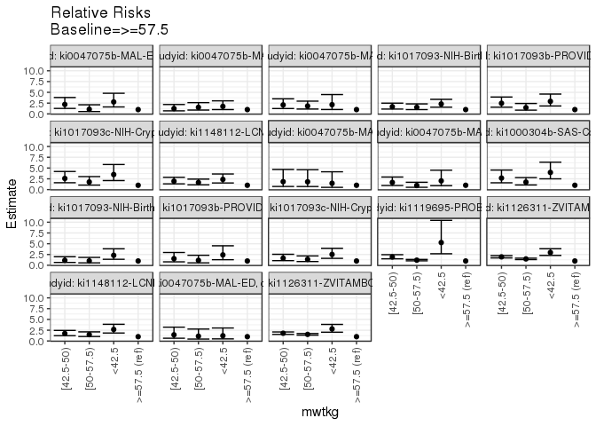

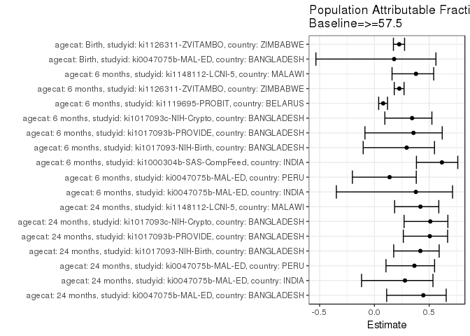

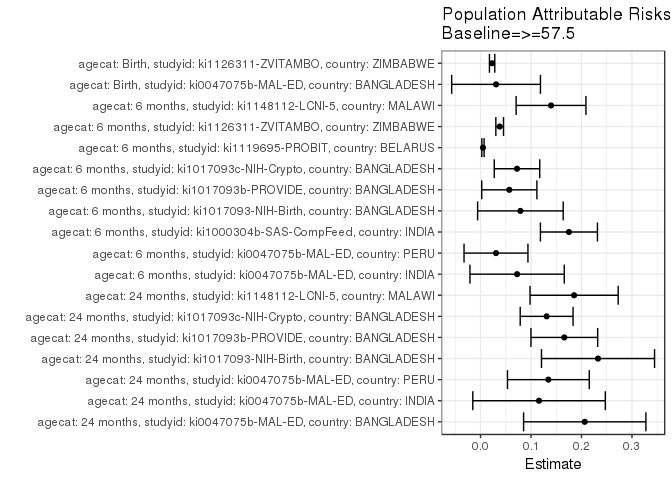

## Results Table

### Parameter: TSM

| agecat | studyid | country | intervention_level | baseline_level | estimate | ci_lower | ci_upper |
| --- | --- | --- | --- | --- | --- | --- | --- |
| Birth | ki0047075b-MAL-ED | BANGLADESH | >=57.5 | NA | 0.1400000 | 0.0436258 | 0.2363742 |
| Birth | ki0047075b-MAL-ED | BANGLADESH | <42.5 | NA | 0.1698113 | 0.0685214 | 0.2711013 |
| Birth | ki0047075b-MAL-ED | BANGLADESH | [42.5-50) | NA | 0.2000000 | 0.1147915 | 0.2852085 |
| Birth | ki0047075b-MAL-ED | BANGLADESH | [50-57.5) | NA | 0.1551724 | 0.0618019 | 0.2485430 |
| Birth | ki1126311-ZVITAMBO | ZIMBABWE | >=57.5 | NA | 0.0783689 | 0.0715450 | 0.0851927 |
| Birth | ki1126311-ZVITAMBO | ZIMBABWE | <42.5 | NA | 0.2191781 | 0.1520714 | 0.2862848 |
| Birth | ki1126311-ZVITAMBO | ZIMBABWE | [42.5-50) | NA | 0.1404899 | 0.1222080 | 0.1587718 |
| Birth | ki1126311-ZVITAMBO | ZIMBABWE | [50-57.5) | NA | 0.1198170 | 0.1090532 | 0.1305808 |
| 6 months | ki0047075b-MAL-ED | INDIA | >=57.5 | NA | 0.1190476 | 0.0208986 | 0.2171967 |
| 6 months | ki0047075b-MAL-ED | INDIA | <42.5 | NA | 0.1739130 | 0.0641455 | 0.2836806 |
| 6 months | ki0047075b-MAL-ED | INDIA | [42.5-50) | NA | 0.2191781 | 0.1240766 | 0.3142796 |
| 6 months | ki0047075b-MAL-ED | INDIA | [50-57.5) | NA | 0.2162162 | 0.1222221 | 0.3102103 |
| 6 months | ki0047075b-MAL-ED | PERU | >=57.5 | NA | 0.1900000 | 0.1129687 | 0.2670313 |
| 6 months | ki0047075b-MAL-ED | PERU | <42.5 | NA | 0.3846154 | 0.1196660 | 0.6495647 |
| 6 months | ki0047075b-MAL-ED | PERU | [42.5-50) | NA | 0.3148148 | 0.1907117 | 0.4389179 |
| 6 months | ki0047075b-MAL-ED | PERU | [50-57.5) | NA | 0.1809524 | 0.1071806 | 0.2547241 |
| 6 months | ki1000304b-SAS-CompFeed | INDIA | >=57.5 | NA | 0.1090909 | 0.0593434 | 0.1588384 |
| 6 months | ki1000304b-SAS-CompFeed | INDIA | <42.5 | NA | 0.4343434 | 0.3580832 | 0.5106037 |
| 6 months | ki1000304b-SAS-CompFeed | INDIA | [42.5-50) | NA | 0.2913257 | 0.2507886 | 0.3318628 |
| 6 months | ki1000304b-SAS-CompFeed | INDIA | [50-57.5) | NA | 0.1891026 | 0.1597269 | 0.2184782 |
| 6 months | ki1017093-NIH-Birth | BANGLADESH | >=57.5 | NA | 0.1891892 | 0.0998700 | 0.2785084 |
| 6 months | ki1017093-NIH-Birth | BANGLADESH | <42.5 | NA | 0.4362416 | 0.3565395 | 0.5159437 |
| 6 months | ki1017093-NIH-Birth | BANGLADESH | [42.5-50) | NA | 0.2173913 | 0.1577376 | 0.2770450 |
| 6 months | ki1017093-NIH-Birth | BANGLADESH | [50-57.5) | NA | 0.1923077 | 0.1244963 | 0.2601191 |
| 6 months | ki1017093b-PROVIDE | BANGLADESH | >=57.5 | NA | 0.1028037 | 0.0452097 | 0.1603978 |
| 6 months | ki1017093b-PROVIDE | BANGLADESH | <42.5 | NA | 0.2482759 | 0.1778983 | 0.3186534 |
| 6 months | ki1017093b-PROVIDE | BANGLADESH | [42.5-50) | NA | 0.1581921 | 0.1043857 | 0.2119985 |
| 6 months | ki1017093b-PROVIDE | BANGLADESH | [50-57.5) | NA | 0.1176471 | 0.0665510 | 0.1687431 |
| 6 months | ki1017093c-NIH-Crypto | BANGLADESH | >=57.5 | NA | 0.1375661 | 0.0884256 | 0.1867067 |
| 6 months | ki1017093c-NIH-Crypto | BANGLADESH | <42.5 | NA | 0.3465347 | 0.2536645 | 0.4394048 |
| 6 months | ki1017093c-NIH-Crypto | BANGLADESH | [42.5-50) | NA | 0.2276786 | 0.1727260 | 0.2826312 |
| 6 months | ki1017093c-NIH-Crypto | BANGLADESH | [50-57.5) | NA | 0.1890547 | 0.1348866 | 0.2432228 |
| 6 months | ki1119695-PROBIT | BELARUS | >=57.5 | NA | 0.0550374 | 0.0420826 | 0.0679923 |
| 6 months | ki1119695-PROBIT | BELARUS | <42.5 | NA | 0.2903226 | 0.0995447 | 0.4811004 |
| 6 months | ki1119695-PROBIT | BELARUS | [42.5-50) | NA | 0.1058601 | 0.0768285 | 0.1348918 |
| 6 months | ki1119695-PROBIT | BELARUS | [50-57.5) | NA | 0.0654308 | 0.0512157 | 0.0796458 |
| 6 months | ki1126311-ZVITAMBO | ZIMBABWE | >=57.5 | NA | 0.1289431 | 0.1189752 | 0.1389110 |
| 6 months | ki1126311-ZVITAMBO | ZIMBABWE | <42.5 | NA | 0.3823529 | 0.2880386 | 0.4766673 |
| 6 months | ki1126311-ZVITAMBO | ZIMBABWE | [42.5-50) | NA | 0.2520492 | 0.2248078 | 0.2792906 |
| 6 months | ki1126311-ZVITAMBO | ZIMBABWE | [50-57.5) | NA | 0.1904006 | 0.1750736 | 0.2057277 |
| 6 months | ki1148112-LCNI-5 | MALAWI | >=57.5 | NA | 0.2283465 | 0.1552975 | 0.3013954 |
| 6 months | ki1148112-LCNI-5 | MALAWI | <42.5 | NA | 0.6111111 | 0.4984396 | 0.7237827 |
| 6 months | ki1148112-LCNI-5 | MALAWI | [42.5-50) | NA | 0.3963964 | 0.3438278 | 0.4489650 |
| 6 months | ki1148112-LCNI-5 | MALAWI | [50-57.5) | NA | 0.3377049 | 0.2845979 | 0.3908120 |
| 24 months | ki0047075b-MAL-ED | BANGLADESH | >=57.5 | NA | 0.2558140 | 0.1250935 | 0.3865344 |
| 24 months | ki0047075b-MAL-ED | BANGLADESH | <42.5 | NA | 0.7111111 | 0.5783708 | 0.8438514 |
| 24 months | ki0047075b-MAL-ED | BANGLADESH | [42.5-50) | NA | 0.5616438 | 0.4475513 | 0.6757364 |
| 24 months | ki0047075b-MAL-ED | BANGLADESH | [50-57.5) | NA | 0.2745098 | 0.1517420 | 0.3972776 |
| 24 months | ki0047075b-MAL-ED | INDIA | >=57.5 | NA | 0.3000000 | 0.1576719 | 0.4423281 |
| 24 months | ki0047075b-MAL-ED | INDIA | <42.5 | NA | 0.5227273 | 0.3748145 | 0.6706400 |
| 24 months | ki0047075b-MAL-ED | INDIA | [42.5-50) | NA | 0.3714286 | 0.2579858 | 0.4848714 |
| 24 months | ki0047075b-MAL-ED | INDIA | [50-57.5) | NA | 0.4583333 | 0.3429876 | 0.5736791 |
| 24 months | ki0047075b-MAL-ED | PERU | >=57.5 | NA | 0.2337662 | 0.1389992 | 0.3285333 |
| 24 months | ki0047075b-MAL-ED | PERU | <42.5 | NA | 0.5000000 | 0.1893287 | 0.8106713 |
| 24 months | ki0047075b-MAL-ED | PERU | [42.5-50) | NA | 0.4871795 | 0.3299167 | 0.6444423 |
| 24 months | ki0047075b-MAL-ED | PERU | [50-57.5) | NA | 0.4266667 | 0.3144523 | 0.5388810 |
| 24 months | ki1017093-NIH-Birth | BANGLADESH | >=57.5 | NA | 0.3220339 | 0.2026671 | 0.4414007 |
| 24 months | ki1017093-NIH-Birth | BANGLADESH | <42.5 | NA | 0.7398374 | 0.6622140 | 0.8174608 |
| 24 months | ki1017093-NIH-Birth | BANGLADESH | [42.5-50) | NA | 0.5374150 | 0.4567199 | 0.6181100 |
| 24 months | ki1017093-NIH-Birth | BANGLADESH | [50-57.5) | NA | 0.4900000 | 0.3919070 | 0.5880930 |
| 24 months | ki1017093b-PROVIDE | BANGLADESH | >=57.5 | NA | 0.1621622 | 0.0935314 | 0.2307929 |
| 24 months | ki1017093b-PROVIDE | BANGLADESH | <42.5 | NA | 0.4718310 | 0.3896520 | 0.5540100 |
| 24 months | ki1017093b-PROVIDE | BANGLADESH | [42.5-50) | NA | 0.4000000 | 0.3262934 | 0.4737066 |
| 24 months | ki1017093b-PROVIDE | BANGLADESH | [50-57.5) | NA | 0.2352941 | 0.1680224 | 0.3025658 |
| 24 months | ki1017093c-NIH-Crypto | BANGLADESH | >=57.5 | NA | 0.1258741 | 0.0714542 | 0.1802941 |
| 24 months | ki1017093c-NIH-Crypto | BANGLADESH | <42.5 | NA | 0.4393939 | 0.3195393 | 0.5592486 |
| 24 months | ki1017093c-NIH-Crypto | BANGLADESH | [42.5-50) | NA | 0.3253012 | 0.2539642 | 0.3966382 |
| 24 months | ki1017093c-NIH-Crypto | BANGLADESH | [50-57.5) | NA | 0.2230216 | 0.1537522 | 0.2922910 |
| 24 months | ki1148112-LCNI-5 | MALAWI | >=57.5 | NA | 0.2558140 | 0.1635190 | 0.3481089 |
| 24 months | ki1148112-LCNI-5 | MALAWI | <42.5 | NA | 0.6041667 | 0.4657023 | 0.7426310 |
| 24 months | ki1148112-LCNI-5 | MALAWI | [42.5-50) | NA | 0.4977778 | 0.4323897 | 0.5631659 |
| 24 months | ki1148112-LCNI-5 | MALAWI | [50-57.5) | NA | 0.4200913 | 0.3546648 | 0.4855178 |

### Parameter: E(Y)

| agecat | studyid | country | intervention_level | baseline_level | estimate | ci_lower | ci_upper |
| --- | --- | --- | --- | --- | --- | --- | --- |
| Birth | ki0047075b-MAL-ED | BANGLADESH | NA | NA | 0.1707317 | 0.1236156 | 0.2178478 |
| Birth | ki1126311-ZVITAMBO | ZIMBABWE | NA | NA | 0.1012739 | 0.0956332 | 0.1069146 |
| 6 months | ki0047075b-MAL-ED | INDIA | NA | NA | 0.1914894 | 0.1410749 | 0.2419038 |
| 6 months | ki0047075b-MAL-ED | PERU | NA | NA | 0.2205882 | 0.1712211 | 0.2699554 |
| 6 months | ki1000304b-SAS-CompFeed | INDIA | NA | NA | 0.2842105 | 0.2659845 | 0.3024365 |
| 6 months | ki1017093-NIH-Birth | BANGLADESH | NA | NA | 0.2681564 | 0.2306532 | 0.3056597 |
| 6 months | ki1017093b-PROVIDE | BANGLADESH | NA | NA | 0.1597938 | 0.1299995 | 0.1895881 |
| 6 months | ki1017093c-NIH-Crypto | BANGLADESH | NA | NA | 0.2097902 | 0.1799252 | 0.2396552 |
| 6 months | ki1119695-PROBIT | BELARUS | NA | NA | 0.0598408 | 0.0469716 | 0.0727101 |
| 6 months | ki1126311-ZVITAMBO | ZIMBABWE | NA | NA | 0.1668346 | 0.1586345 | 0.1750346 |
| 6 months | ki1148112-LCNI-5 | MALAWI | NA | NA | 0.3679809 | 0.3352903 | 0.4006715 |
| 24 months | ki0047075b-MAL-ED | BANGLADESH | NA | NA | 0.4622642 | 0.3949918 | 0.5295365 |
| 24 months | ki0047075b-MAL-ED | INDIA | NA | NA | 0.4159292 | 0.3515272 | 0.4803312 |
| 24 months | ki0047075b-MAL-ED | PERU | NA | NA | 0.3681592 | 0.3013164 | 0.4350020 |
| 24 months | ki1017093-NIH-Birth | BANGLADESH | NA | NA | 0.5547786 | 0.5076945 | 0.6018626 |
| 24 months | ki1017093b-PROVIDE | BANGLADESH | NA | NA | 0.3281250 | 0.2897474 | 0.3665026 |
| 24 months | ki1017093c-NIH-Crypto | BANGLADESH | NA | NA | 0.2568093 | 0.2190047 | 0.2946140 |
| 24 months | ki1148112-LCNI-5 | MALAWI | NA | NA | 0.4411765 | 0.4006626 | 0.4816903 |

### Parameter: RR

| agecat | studyid | country | intervention_level | baseline_level | estimate | ci_lower | ci_upper |
| --- | --- | --- | --- | --- | --- | --- | --- |
| Birth | ki0047075b-MAL-ED | BANGLADESH | >=57.5 | >=57.5 | 1.000000 | 1.0000000 | 1.000000 |
| Birth | ki0047075b-MAL-ED | BANGLADESH | <42.5 | >=57.5 | 1.212938 | 0.4878157 | 3.015931 |
| Birth | ki0047075b-MAL-ED | BANGLADESH | [42.5-50) | >=57.5 | 1.428571 | 0.6357904 | 3.209888 |
| Birth | ki0047075b-MAL-ED | BANGLADESH | [50-57.5) | >=57.5 | 1.108374 | 0.4442330 | 2.765427 |
| Birth | ki1126311-ZVITAMBO | ZIMBABWE | >=57.5 | >=57.5 | 1.000000 | 1.0000000 | 1.000000 |
| Birth | ki1126311-ZVITAMBO | ZIMBABWE | <42.5 | >=57.5 | 2.796750 | 2.0342815 | 3.844999 |
| Birth | ki1126311-ZVITAMBO | ZIMBABWE | [42.5-50) | >=57.5 | 1.792675 | 1.5328590 | 2.096530 |
| Birth | ki1126311-ZVITAMBO | ZIMBABWE | [50-57.5) | >=57.5 | 1.528885 | 1.3490895 | 1.732643 |
| 6 months | ki0047075b-MAL-ED | INDIA | >=57.5 | >=57.5 | 1.000000 | 1.0000000 | 1.000000 |
| 6 months | ki0047075b-MAL-ED | INDIA | <42.5 | >=57.5 | 1.460870 | 0.5172244 | 4.126139 |
| 6 months | ki0047075b-MAL-ED | INDIA | [42.5-50) | >=57.5 | 1.841096 | 0.7252063 | 4.674027 |
| 6 months | ki0047075b-MAL-ED | INDIA | [50-57.5) | >=57.5 | 1.816216 | 0.7151321 | 4.612632 |
| 6 months | ki0047075b-MAL-ED | PERU | >=57.5 | >=57.5 | 1.000000 | 1.0000000 | 1.000000 |
| 6 months | ki0047075b-MAL-ED | PERU | <42.5 | >=57.5 | 2.024291 | 0.9101922 | 4.502078 |
| 6 months | ki0047075b-MAL-ED | PERU | [42.5-50) | >=57.5 | 1.656920 | 0.9412708 | 2.916678 |
| 6 months | ki0047075b-MAL-ED | PERU | [50-57.5) | >=57.5 | 0.952381 | 0.5359306 | 1.692438 |
| 6 months | ki1000304b-SAS-CompFeed | INDIA | >=57.5 | >=57.5 | 1.000000 | 1.0000000 | 1.000000 |
| 6 months | ki1000304b-SAS-CompFeed | INDIA | <42.5 | >=57.5 | 3.981482 | 2.4938168 | 6.356600 |
| 6 months | ki1000304b-SAS-CompFeed | INDIA | [42.5-50) | >=57.5 | 2.670485 | 1.5733409 | 4.532707 |
| 6 months | ki1000304b-SAS-CompFeed | INDIA | [50-57.5) | >=57.5 | 1.733440 | 1.0773678 | 2.789033 |
| 6 months | ki1017093-NIH-Birth | BANGLADESH | >=57.5 | >=57.5 | 1.000000 | 1.0000000 | 1.000000 |
| 6 months | ki1017093-NIH-Birth | BANGLADESH | <42.5 | >=57.5 | 2.305849 | 1.3898757 | 3.825477 |
| 6 months | ki1017093-NIH-Birth | BANGLADESH | [42.5-50) | >=57.5 | 1.149068 | 0.6655652 | 1.983815 |
| 6 months | ki1017093-NIH-Birth | BANGLADESH | [50-57.5) | >=57.5 | 1.016484 | 0.5638787 | 1.832378 |
| 6 months | ki1017093b-PROVIDE | BANGLADESH | >=57.5 | >=57.5 | 1.000000 | 1.0000000 | 1.000000 |
| 6 months | ki1017093b-PROVIDE | BANGLADESH | <42.5 | >=57.5 | 2.415047 | 1.2889840 | 4.524844 |
| 6 months | ki1017093b-PROVIDE | BANGLADESH | [42.5-50) | >=57.5 | 1.538778 | 0.7989845 | 2.963558 |
| 6 months | ki1017093b-PROVIDE | BANGLADESH | [50-57.5) | >=57.5 | 1.144385 | 0.5632682 | 2.325033 |
| 6 months | ki1017093c-NIH-Crypto | BANGLADESH | >=57.5 | >=57.5 | 1.000000 | 1.0000000 | 1.000000 |
| 6 months | ki1017093c-NIH-Crypto | BANGLADESH | <42.5 | >=57.5 | 2.519040 | 1.6117314 | 3.937110 |
| 6 months | ki1017093c-NIH-Crypto | BANGLADESH | [42.5-50) | >=57.5 | 1.655048 | 1.0754286 | 2.547063 |
| 6 months | ki1017093c-NIH-Crypto | BANGLADESH | [50-57.5) | >=57.5 | 1.374282 | 0.8693636 | 2.172454 |
| 6 months | ki1119695-PROBIT | BELARUS | >=57.5 | >=57.5 | 1.000000 | 1.0000000 | 1.000000 |
| 6 months | ki1119695-PROBIT | BELARUS | <42.5 | >=57.5 | 5.275004 | 2.6704763 | 10.419742 |
| 6 months | ki1119695-PROBIT | BELARUS | [42.5-50) | >=57.5 | 1.923421 | 1.5031473 | 2.461202 |
| 6 months | ki1119695-PROBIT | BELARUS | [50-57.5) | >=57.5 | 1.188841 | 1.0353018 | 1.365152 |
| 6 months | ki1126311-ZVITAMBO | ZIMBABWE | >=57.5 | >=57.5 | 1.000000 | 1.0000000 | 1.000000 |
| 6 months | ki1126311-ZVITAMBO | ZIMBABWE | <42.5 | >=57.5 | 2.965284 | 2.2898233 | 3.839994 |
| 6 months | ki1126311-ZVITAMBO | ZIMBABWE | [42.5-50) | >=57.5 | 1.954731 | 1.7115037 | 2.232525 |
| 6 months | ki1126311-ZVITAMBO | ZIMBABWE | [50-57.5) | >=57.5 | 1.476625 | 1.3206874 | 1.650975 |
| 6 months | ki1148112-LCNI-5 | MALAWI | >=57.5 | >=57.5 | 1.000000 | 1.0000000 | 1.000000 |
| 6 months | ki1148112-LCNI-5 | MALAWI | <42.5 | >=57.5 | 2.676245 | 1.8499965 | 3.871515 |
| 6 months | ki1148112-LCNI-5 | MALAWI | [42.5-50) | >=57.5 | 1.735943 | 1.2278292 | 2.454330 |
| 6 months | ki1148112-LCNI-5 | MALAWI | [50-57.5) | >=57.5 | 1.478915 | 1.0354552 | 2.112297 |
| 24 months | ki0047075b-MAL-ED | BANGLADESH | >=57.5 | >=57.5 | 1.000000 | 1.0000000 | 1.000000 |
| 24 months | ki0047075b-MAL-ED | BANGLADESH | <42.5 | >=57.5 | 2.779798 | 1.6134154 | 4.789391 |
| 24 months | ki0047075b-MAL-ED | BANGLADESH | [42.5-50) | >=57.5 | 2.195517 | 1.2668354 | 3.804988 |
| 24 months | ki0047075b-MAL-ED | BANGLADESH | [50-57.5) | >=57.5 | 1.073084 | 0.5441509 | 2.116157 |
| 24 months | ki0047075b-MAL-ED | INDIA | >=57.5 | >=57.5 | 1.000000 | 1.0000000 | 1.000000 |
| 24 months | ki0047075b-MAL-ED | INDIA | <42.5 | >=57.5 | 1.742424 | 1.0028782 | 3.027329 |
| 24 months | ki0047075b-MAL-ED | INDIA | [42.5-50) | >=57.5 | 1.238095 | 0.7042206 | 2.176704 |
| 24 months | ki0047075b-MAL-ED | INDIA | [50-57.5) | >=57.5 | 1.527778 | 0.8929461 | 2.613937 |
| 24 months | ki0047075b-MAL-ED | PERU | >=57.5 | >=57.5 | 1.000000 | 1.0000000 | 1.000000 |
| 24 months | ki0047075b-MAL-ED | PERU | <42.5 | >=57.5 | 2.138889 | 1.0185607 | 4.491481 |
| 24 months | ki0047075b-MAL-ED | PERU | [42.5-50) | >=57.5 | 2.084046 | 1.2412243 | 3.499163 |
| 24 months | ki0047075b-MAL-ED | PERU | [50-57.5) | >=57.5 | 1.825185 | 1.1257499 | 2.959184 |
| 24 months | ki1017093-NIH-Birth | BANGLADESH | >=57.5 | >=57.5 | 1.000000 | 1.0000000 | 1.000000 |
| 24 months | ki1017093-NIH-Birth | BANGLADESH | <42.5 | >=57.5 | 2.297390 | 1.5629033 | 3.377048 |
| 24 months | ki1017093-NIH-Birth | BANGLADESH | [42.5-50) | >=57.5 | 1.668815 | 1.1187253 | 2.489390 |
| 24 months | ki1017093-NIH-Birth | BANGLADESH | [50-57.5) | >=57.5 | 1.521579 | 0.9984793 | 2.318729 |
| 24 months | ki1017093b-PROVIDE | BANGLADESH | >=57.5 | >=57.5 | 1.000000 | 1.0000000 | 1.000000 |
| 24 months | ki1017093b-PROVIDE | BANGLADESH | <42.5 | >=57.5 | 2.909624 | 1.8411009 | 4.598289 |
| 24 months | ki1017093b-PROVIDE | BANGLADESH | [42.5-50) | >=57.5 | 2.466667 | 1.5546815 | 3.913628 |
| 24 months | ki1017093b-PROVIDE | BANGLADESH | [50-57.5) | >=57.5 | 1.450980 | 0.8706596 | 2.418103 |
| 24 months | ki1017093c-NIH-Crypto | BANGLADESH | >=57.5 | >=57.5 | 1.000000 | 1.0000000 | 1.000000 |
| 24 months | ki1017093c-NIH-Crypto | BANGLADESH | <42.5 | >=57.5 | 3.490741 | 2.0936724 | 5.820047 |
| 24 months | ki1017093c-NIH-Crypto | BANGLADESH | [42.5-50) | >=57.5 | 2.584337 | 1.5915302 | 4.196464 |
| 24 months | ki1017093c-NIH-Crypto | BANGLADESH | [50-57.5) | >=57.5 | 1.771783 | 1.0404444 | 3.017185 |
| 24 months | ki1148112-LCNI-5 | MALAWI | >=57.5 | >=57.5 | 1.000000 | 1.0000000 | 1.000000 |
| 24 months | ki1148112-LCNI-5 | MALAWI | <42.5 | >=57.5 | 2.361742 | 1.5402938 | 3.621275 |
| 24 months | ki1148112-LCNI-5 | MALAWI | [42.5-50) | >=57.5 | 1.945859 | 1.3254402 | 2.856685 |
| 24 months | ki1148112-LCNI-5 | MALAWI | [50-57.5) | >=57.5 | 1.642175 | 1.1085495 | 2.432674 |

### Parameter: PAR

| agecat | studyid | country | intervention_level | baseline_level | estimate | ci_lower | ci_upper |
| --- | --- | --- | --- | --- | --- | --- | --- |
| Birth | ki0047075b-MAL-ED | BANGLADESH | >=57.5 | NA | 0.0307317 | -0.0572019 | 0.1186653 |
| Birth | ki1126311-ZVITAMBO | ZIMBABWE | >=57.5 | NA | 0.0229050 | 0.0176244 | 0.0281857 |
| 6 months | ki0047075b-MAL-ED | INDIA | >=57.5 | NA | 0.0724417 | -0.0210007 | 0.1658842 |
| 6 months | ki0047075b-MAL-ED | PERU | >=57.5 | NA | 0.0305882 | -0.0327192 | 0.0938957 |
| 6 months | ki1000304b-SAS-CompFeed | INDIA | >=57.5 | NA | 0.1751196 | 0.1186431 | 0.2315962 |
| 6 months | ki1017093-NIH-Birth | BANGLADESH | >=57.5 | NA | 0.0789672 | -0.0058010 | 0.1637355 |
| 6 months | ki1017093b-PROVIDE | BANGLADESH | >=57.5 | NA | 0.0569901 | 0.0023540 | 0.1116261 |
| 6 months | ki1017093c-NIH-Crypto | BANGLADESH | >=57.5 | NA | 0.0722241 | 0.0271677 | 0.1172805 |
| 6 months | ki1119695-PROBIT | BELARUS | >=57.5 | NA | 0.0048034 | 0.0025676 | 0.0070393 |
| 6 months | ki1126311-ZVITAMBO | ZIMBABWE | >=57.5 | NA | 0.0378914 | 0.0302800 | 0.0455028 |
| 6 months | ki1148112-LCNI-5 | MALAWI | >=57.5 | NA | 0.1396344 | 0.0704572 | 0.2088117 |
| 24 months | ki0047075b-MAL-ED | BANGLADESH | >=57.5 | NA | 0.2064502 | 0.0852828 | 0.3276176 |
| 24 months | ki0047075b-MAL-ED | INDIA | >=57.5 | NA | 0.1159292 | -0.0153498 | 0.2472082 |
| 24 months | ki0047075b-MAL-ED | PERU | >=57.5 | NA | 0.1343930 | 0.0533501 | 0.2154358 |
| 24 months | ki1017093-NIH-Birth | BANGLADESH | >=57.5 | NA | 0.2327447 | 0.1207348 | 0.3447545 |
| 24 months | ki1017093b-PROVIDE | BANGLADESH | >=57.5 | NA | 0.1659628 | 0.0998747 | 0.2320510 |
| 24 months | ki1017093c-NIH-Crypto | BANGLADESH | >=57.5 | NA | 0.1309352 | 0.0785628 | 0.1833076 |
| 24 months | ki1148112-LCNI-5 | MALAWI | >=57.5 | NA | 0.1853625 | 0.0980421 | 0.2726829 |

### Parameter: PAF

| agecat | studyid | country | intervention_level | baseline_level | estimate | ci_lower | ci_upper |
| --- | --- | --- | --- | --- | --- | --- | --- |
| Birth | ki0047075b-MAL-ED | BANGLADESH | >=57.5 | NA | 0.1800000 | -0.5337384 | 0.5615941 |
| Birth | ki1126311-ZVITAMBO | ZIMBABWE | >=57.5 | NA | 0.2261692 | 0.1735894 | 0.2754036 |
| 6 months | ki0047075b-MAL-ED | INDIA | >=57.5 | NA | 0.3783069 | -0.3471440 | 0.7130950 |
| 6 months | ki0047075b-MAL-ED | PERU | >=57.5 | NA | 0.1386667 | -0.2007227 | 0.3821262 |
| 6 months | ki1000304b-SAS-CompFeed | INDIA | >=57.5 | NA | 0.6161616 | 0.3835752 | 0.7609896 |
| 6 months | ki1017093-NIH-Birth | BANGLADESH | >=57.5 | NA | 0.2944820 | -0.1022984 | 0.5484384 |
| 6 months | ki1017093b-PROVIDE | BANGLADESH | >=57.5 | NA | 0.3566476 | -0.0862704 | 0.6189693 |
| 6 months | ki1017093c-NIH-Crypto | BANGLADESH | >=57.5 | NA | 0.3442681 | 0.0952388 | 0.5247538 |
| 6 months | ki1119695-PROBIT | BELARUS | >=57.5 | NA | 0.0802700 | 0.0389779 | 0.1197879 |
| 6 months | ki1126311-ZVITAMBO | ZIMBABWE | >=57.5 | NA | 0.2271198 | 0.1811340 | 0.2705230 |
| 6 months | ki1148112-LCNI-5 | MALAWI | >=57.5 | NA | 0.3794611 | 0.1610234 | 0.5410259 |
| 24 months | ki0047075b-MAL-ED | BANGLADESH | >=57.5 | NA | 0.4466065 | 0.1119606 | 0.6551456 |
| 24 months | ki0047075b-MAL-ED | INDIA | >=57.5 | NA | 0.2787234 | -0.1173678 | 0.5344058 |
| 24 months | ki0047075b-MAL-ED | PERU | >=57.5 | NA | 0.3650404 | 0.1056168 | 0.5492159 |
| 24 months | ki1017093-NIH-Birth | BANGLADESH | >=57.5 | NA | 0.4195271 | 0.1760826 | 0.5910406 |
| 24 months | ki1017093b-PROVIDE | BANGLADESH | >=57.5 | NA | 0.5057915 | 0.2639459 | 0.6681738 |
| 24 months | ki1017093c-NIH-Crypto | BANGLADESH | >=57.5 | NA | 0.5098538 | 0.2709787 | 0.6704578 |
| 24 months | ki1148112-LCNI-5 | MALAWI | >=57.5 | NA | 0.4201550 | 0.1847002 | 0.5876116 |